# Predicting Barbell-Lift Execution from Wearable Sensors

Ahmed

juillet 23, 2026

## Executive summary

I built a bagged classification-tree ensemble to predict the five exercise classes from belt, arm, forearm, and dumbbell accelerometers. After removing identifiers, timestamps, window fields, and variables with at least 5% missing values, 52 sensor predictors remained. Stratified five-fold cross-validation produced **99.19% accuracy**, so the estimated out-of-sample error is **0.81%**. The final ensemble was trained on all 19,622 observations and generated the 20 quiz predictions listed below.

## Data preparation and exploratory analysis

The response `classe` records correct execution (A) and four specific errors (B–E). The seven administrative variables were excluded because they describe the observation or collection window rather than body motion and could cause spurious participant/time leakage. The original data also contain summary variables that are almost entirely missing; columns with 5% or more missing values were removed. The retained predictors are complete in both datasets, so imputation was unnecessary.

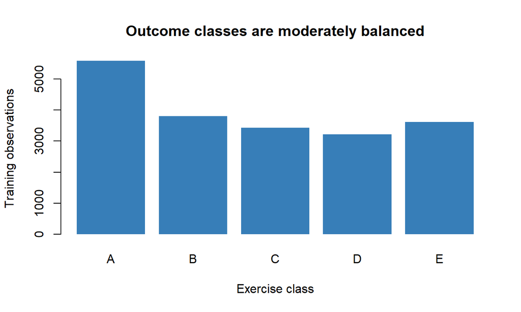

Class A is most common, but every class has more than 3,000 observations. Stratification therefore preserves the class distribution in every validation fold and prevents the accuracy estimate from being dominated by class A.

## Model and cross-validation

Classification trees accommodate nonlinear relationships and interactions without requiring sensor scaling. A single deep tree is unstable, so I fitted an ensemble of 35 bootstrap trees per validation fold. Each tree used a random subset of 35 of the 52 predictors; majority voting reduced variance and supplied additional diversity. The tree controls were `cp = 0`, `minsplit = 5`, `minbucket = 2`, and `maxdepth = 30`.

Five stratified folds were created once with seed 20260723. For each fold, the model was trained on the other four folds and evaluated only on the held-out observations. This makes every observation an out-of-fold prediction and avoids using the 20 quiz cases for model selection.

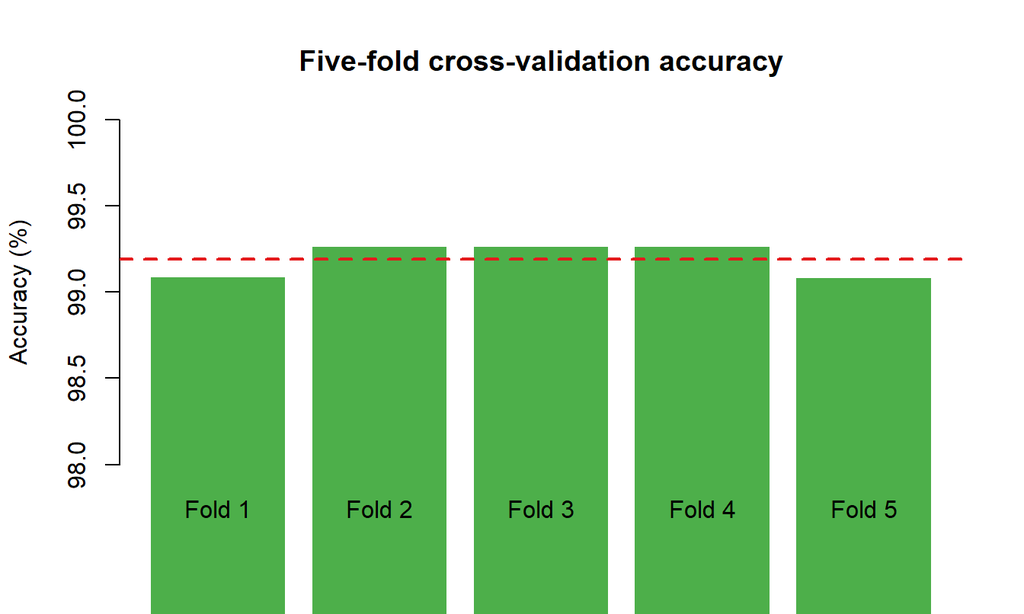

Fold accuracies ranged from 99.08% to 99.26%. The pooled confusion matrix is:

```r
res$cv_confusion
```

```
##         Predicted
## Observed    A    B    C    D    E
##        A 5570    8    1    1    0
##        B   31 3752   14    0    0
##        C    0   22 3391    9    0
##        D    1    0   45 3167    3
##        E    0    3    4   17 3583
```

The pooled cross-validated error, 0.81%, is the expected out-of-sample error. It is preferable to training accuracy because each prediction was made by a model that did not see that observation. Remaining error may reflect similar motion patterns between incorrect techniques and participant-specific variation.

## Final model and quiz predictions

After validation, I trained 75 bootstrap trees on all training observations using the same preprocessing and settings. The resulting predictions are:

| problem_id | prediction |
| --- | --- |
| 1 | B |
| 2 | A |
| 3 | B |
| 4 | A |
| 5 | A |
| 6 | E |
| 7 | D |
| 8 | B |
| 9 | A |
| 10 | A |
| 11 | B |
| 12 | C |
| 13 | B |
| 14 | A |
| 15 | E |
| 16 | E |
| 17 | A |
| 18 | B |
| 19 | B |
| 20 | B |

The comma-separated answer file and 20 one-answer text files are included in the repository. The complete reusable fitting code is in `train_model.R`.

## Data citation

Velloso, E., Bulling, A., Gellersen, H., Ugulino, W., and Fuks, H. (2013). *Qualitative Activity Recognition of Weight Lifting Exercises*. Proceedings of the 4th Augmented Human International Conference.